# LA Restaurant Review Analysis

## Ali Ladha, Chase Pattee, Gaurav Mishra, Robby Stohel

### 2025-07-27

# Executive Summary

This project presents a comprehensive natural language processing (NLP) pipeline designed to analyze customer reviews of 240 top-rated restaurants in Los Angeles. The goal of the analysis was to extract insights into sentiment polarity, emotional tone, and key thematic topics present in customer feedback. The pipeline was implemented using Python and industry-standard NLP libraries, and the methodology focused entirely on transforming raw textual data into interpretable emotional and thematic patterns.

The analysis began with a structured approach to data preparation. The dataset included review text, star ratings, restaurant names, and pricing tiers. Initial preprocessing addressed missing values in categorical and numerical fields. The core text preprocessing pipeline included contraction expansion, spelling correction using the SymSpell algorithm, named entity recognition, part-of-speech filtering, stopword customization, lemmatization, and phrase modeling. This created a clean and semantically meaningful version of the text for further analysis.

Two major components of sentiment analysis were implemented. First, TextBlob was used to assign a continuous polarity score ranging from -1 (negative) to +1 (positive) to each review. Second, emotional content was quantified using the NRC Emotion Lexicon, yielding normalized scores across ten emotions: joy, trust, anticipation, positive, surprise, sadness, fear, anger, disgust, and negative. These values provided a multidimensional emotional fingerprint for each review.

To uncover the deeper thematic structure of the reviews, Latent Dirichlet Allocation (LDA) was used for topic modeling. Preprocessing for this step included additional part-of-speech filtering (nouns and adjectives only) and vectorization using a count-based document-term matrix. After evaluating models with 2 to 14 topics using log-likelihood and perplexity, a 5-topic model was selected for its balance of coherence and interpretability. Each review was then assigned a topic distribution, and the most dominant topic was identified and appended to the data.

The final stage of analysis focused on comparing sentiment polarity and emotional scores across topics. Average polarity scores and normalized emotion proportions were computed for each dominant topic, revealing how different thematic elements - such as food quality, service, or ambiance - were associated with specific emotional experiences. Radar and bar plots were used to visualize these relationships.

This end-to-end NLP pipeline resulted in a richly annotated dataset that links sentiment and emotion with latent themes in customer reviews. The approach enables restaurant stakeholders to interpret unstructured customer feedback through the lenses of emotional response and thematic focus, offering practical insight into what aspects of the dining experience matter most to their clientele.

# Methodology

This study presents a multi-step natural language processing pipeline for analyzing customer reviews of restaurants in Los Angeles. The analysis focuses on extracting sentiment polarity, emotional content, and latent thematic structures to uncover patterns in customer feedback. The methodology includes data ingestion, text preprocessing, sentiment and emotion scoring, topic modeling, and sentiment analysis by topic. All steps are applied using Python and several key NLP libraries within a reproducible pipeline.

### Data Collection and Initial Preparation

The dataset used for this analysis contains user reviews and metadata for 240 top-rated restaurants in Los Angeles. It was read into a pandas DataFrame and included variables such as restaurant name, star rating, date, price tier, and a free-text review column. Missing values in the categorical fields (*RestaurantName*, *Price*) were imputed using placeholder values. Numeric fields with missing entries were filled with zeros.

### Text Preprocessing

To prepare the textual data for analysis, a robust preprocessing pipeline was developed with the following steps:

- **Contraction Expansion**: All English contractions were expanded to their full forms using the *contractions* library.
- **Spelling Correction**: Misspelled words were corrected using the SymSpell algorithm and a preloaded frequency dictionary.
- **Lowercasing and Cleaning**: All characters were lowercased, and non-alphabetic characters were removed.
- **Named Entity Consolidation**: Multi-word named entities identified by SpaCy’s NER engine were joined with underscores to preserve their semantic unity.
- **Token Filtering**: Using SpaCy’s POS tagger, only nouns, adjectives, verbs, adverbs, particles, and conjunctions were retained. Custom stopword filtering preserved key sentiment-bearing words, including negators (e.g., *not*, *never*) and intensifiers (e.g., *very*, *absolutely*).
- **Lemmatization**: All retained tokens were lemmatized to their base forms.
- **Phrase Modeling**: Common bigrams and trigrams were identified using Gensim's *Phrases* and merged into single tokens.
- **Rejoining Tokens**: Cleaned and tokenized text was joined back into space-separated strings for downstream modeling.

The result was stored as a new *clean_text* column.

### Sentiment and Emotion Scoring

Two scoring components were implemented to quantify sentiment:

- **Polarity Scoring**: TextBlob was used to assign a sentiment polarity score to each review, ranging from -1 (most negative) to +1 (most positive).
- **Emotion Scoring**: The NRC Emotion Lexicon, accessed via the NRCLex library, provided normalized emotion scores for ten emotional dimensions: *joy*, *positive*, *trust*, *fear*, *negative*, *anticipation*, *sadness*, *anger*, *disgust*, and *surprise*. Emotion counts were normalized to produce proportion scores.

Both scorers were wrapped in custom scikit-learn transformers and applied sequentially using a unified pipeline. Resulting scores were appended to the main DataFrame for each review.

### Categorical Feature Encoding

Restaurant names were encoded using scikit-learn's *OrdinalEncoder* to convert string labels into numeric codes. The *Price* field, originally containing symbols such as `$` or `$$$`, was mapped to ordinal integers from 1 to 4. Missing entries were set to 0. This will allow us to implement predictive analytics should we wish to expand upon the analysis.

### Topic Modeling via Latent Dirichlet Allocation (LDA)

To extract latent thematic topics:

- **POS Filtering for LDA**: For more coherent topic modeling, a separate filtered version of the text was created (*lda_clean_text*). This retained only nouns and adjectives after lemmatization and removed stopwords and non-alphabetic tokens.
- **Vectorization**: The filtered text was vectorized into a document-term matrix using *CountVectorizer*, with *min_df=2*, *max_df=0.95*, and English stopwords removed.
- **Model Selection**: LDA models were trained for a range of topic counts (2-14). Log-likelihood and perplexity were computed to evaluate model fit. A 5-topic model was ultimately selected as a balance between interpretability and statistical performance.
- **Topic Assignment**: Each document was assigned a vector of topic proportions, which was appended to the original DataFrame. The dominant topic per review was defined as the topic with the highest proportion.

### Sentiment Analysis by Topic

To connect sentiment and emotional tone with underlying themes:

- **Average Polarity by Topic**: Mean polarity scores were computed for each dominant topic to assess the sentiment associated with each theme.
- **Average Emotion by Topic**: The same was done for each emotion dimension, yielding a detailed emotional profile for each topic.

Visualizations, including bar charts and radar plots, were generated to compare sentiment and emotion distributions across topics.

### Visualization and Interpretation

Key plots included:

- A radar chart summarizing average emotion levels across all reviews.
- Bar plots comparing average polarity and emotion proportions by dominant topic.

These visualizations enabled intuitive interpretations of emotional trends and sentiment distribution tied to specific aspects of the dining experience.

This methodology produced a multi-dimensional understanding of customer feedback, uncovering both broad emotional tone and specific thematic concerns. It supports data-driven insights into how diners perceive food, service, ambiance, and other key elements across a competitive urban restaurant landscape.

# Analysis Results

## Initial Setup

```python
# Standard library
import contextlib
import io
import os
import re

# Typing
from typing import List, Optional, Union, Dict, Set, Tuple

# Third-party libraries
import contractions
import matplotlib.pyplot as plt
import numpy as np
import pandas as pd
import requests
import spacy
from gensim.models import Phrases
from gensim.models.phrases import Phraser
from nrclex import NRCLex
from sklearn.base import BaseEstimator, TransformerMixin
from sklearn.decomposition import TruncatedSVD, LatentDirichletAllocation
from sklearn.feature_extraction.text import CountVectorizer, TfidfVectorizer
from sklearn.pipeline import Pipeline
from sklearn.preprocessing import OrdinalEncoder
from symspellpy.symspellpy import SymSpell, Verbosity
from textblob import TextBlob
from tqdm import tqdm


# Unified emotion color theme
emotion_colors = {
    "emotion_joy": "#1abc9c",
    "emotion_positive": "#2ecc71",
    "emotion_trust": "#3498db",
    "emotion_fear": "#9b59b6",
    "emotion_negative": "#e74c3c",
    "emotion_anticipation": "#f39c12",
    "emotion_sadness": "#95a5a6",
    "emotion_anger": "#e67e22",
    "emotion_disgust": "#7f8c8d",
    "emotion_surprise": "#34495e"
}

# Main accent color for neutral plots
main_color = emotion_colors["emotion_trust"]  # Sky blue

# Load input dataset
df = pd.read_csv("top 240 restaurants recommanded in los angeles 2.csv")
```

## Corpus Preprocessing

To prepare the textual data for analysis, we designed and applied a comprehensive preprocessing pipeline that addressed various forms of noise and inconsistency in the raw reviews. Our goal was to standardize the input text while preserving semantically meaningful structures and important modifiers such as negators and intensifiers.

We began with **text normalization**, where we first expanded contractions (e.g., “don’t” to “do not”) to their full forms. We then applied **automated spelling correction** using the SymSpell algorithm, which efficiently corrected common typographical errors based on a frequency dictionary. This helped reduce vocabulary sparsity caused by misspellings.

Following this, we converted all characters to lowercase and removed non-alphabetic symbols to simplify the token space. We also utilized a named entity recognition step to detect multi-word named entities (e.g., "Los Angeles") and replaced them with underscore-joined versions (e.g., "los_angeles") to treat them as single semantic units throughout the analysis.

Linguistically, we filtered tokens based on part-of-speech tagging, retaining only nouns, adjectives, verbs, adverbs, particles, and conjunctions. This helped us remove less informative words like determiners or interjections. Additionally, we implemented a custom stopword filtering strategy. Instead of discarding all common stopwords, we retained important **negation terms** (e.g., “not”, “never”) and **positive intensifiers** (e.g., “very”, “definitely”) to preserve key sentiment-bearing words often removed by default filters.

After lemmatization and token filtering, we applied a **phrase modeling step** to detect and consolidate frequent bigrams and trigrams (e.g., "ice cream", "chicken tikka masala") into single tokens. This ensured multi-word expressions were treated as cohesive units, improving the semantic richness of downstream analyses.

Finally, the cleaned and tokenized lists were joined back into processed text strings, ready for modeling or vectorization. This preprocessing pipeline was applied to all customer review texts in the dataset, and the resulting clean texts were stored in a new column for subsequent analysis.

```python
def load_spacy_model(model_name: str = "en_core_web_sm") -> spacy.language.Language:
    """
    Load the SpaCy NLP model, downloading it if needed.
    """
    try:
        return spacy.load(model_name)
    except OSError:
        buf = io.StringIO()
        with contextlib.redirect_stdout(buf), contextlib.redirect_stderr(buf):
            spacy.cli.download(model_name)
        return spacy.load(model_name)


class SpellingCorrector:
    """
    Corrects spelling errors using the SymSpell algorithm.
    """

    def __init__(self, dictionary_path: str = "data/frequency_dictionary_en_82_765.txt") -> None:
        self.sym_spell = SymSpell(max_dictionary_edit_distance=2, prefix_length=7)
        if not os.path.exists(dictionary_path):
            os.makedirs("data", exist_ok=True)
            url = (
                "https://raw.githubusercontent.com/mammothb/symspellpy/master/"
                "symspellpy/frequency_dictionary_en_82_765.txt"
            )
            r = requests.get(url)
            with open(dictionary_path, "wb") as f:
                f.write(r.content)
        self.sym_spell.load_dictionary(dictionary_path, 0, 1)

    def correct_text(self, text: str) -> str:
        """
        Apply spelling correction to each word in the input string.
        """
        words = text.split()
        corrected = []
        for word in words:
            suggestions = self.sym_spell.lookup(word, Verbosity.CLOSEST, max_edit_distance=2)
            corrected.append(suggestions[0].term if suggestions else word)
        return " ".join(corrected)


class TextPreprocessor(BaseEstimator, TransformerMixin):
    """
    Applies text normalization, spelling correction, named entity grouping,
    lemmatization, and stopword filtering.
    """

    def __init__(self, negators: Optional[set] = None, intensifiers: Optional[set] = None) -> None:
        self.negators = negators or {
            "not", "no", "nor", "never", "none", "nothing", "nowhere", "neither",
            "without", "barely", "hardly", "scarcely", "rarely", "seldom",
        }
        self.intensifiers = intensifiers or {
            "always", "definitely", "absolutely", "certainly", "clearly", "indeed",
            "surely", "truly", "very", "really", "extremely", "completely", "totally",
            "highly", "greatly", "positively", "successfully", "frequently", "often",
        }
        self.custom_stopwords = nlp.Defaults.stop_words \
            .difference(self.negators).difference(self.intensifiers)
        self.allowed_pos = {"NOUN", "ADJ", "VERB", "ADV", "PART", "CONJ"}
        self.corrector = SpellingCorrector()

    def fit(self, X, y=None):
        return self

    def transform(self, X: pd.Series) -> pd.Series:
        """
        Preprocess each document in the input series.
        """
        tqdm.pandas(desc="Preprocessing")
        return X.progress_apply(self._process)

    def _process(self, text: str) -> List[str]:
        """
        Clean, normalize, and tokenize input text.
        """
        try:
            if pd.isnull(text):
                return []

            text = contractions.fix(str(text))
            text = self.corrector.correct_text(text)
            text = text.lower()
            text = re.sub(r"[^a-z\s]", "", text)

            doc = nlp(text)

            ent_tokens = {
                ent.text.lower(): ent.text.lower().replace(" ", "_")
                for ent in doc.ents if len(ent.text.split()) > 1
            }

            modified_text = text
            for original, underscored in ent_tokens.items():
                modified_text = modified_text.replace(original, underscored)

            doc = nlp(modified_text)

            tokens = []
            for token in doc:
                t = token.text.lower()
                if token.is_space:
                    continue
                if t in self.negators or t in self.intensifiers:
                    tokens.append(t)
                elif token.pos_ in self.allowed_pos and t not in self.custom_stopwords:
                    tokens.append(token.lemma_)

            return tokens

        except Exception as e:
            print(f"Error on: {text[:30]}... => {e}")
            return []


class PhraseModeler(BaseEstimator, TransformerMixin):
    """
    Detects and merges common bigrams and trigrams from tokenized documents.
    """

    def __init__(self, min_count: int = 5, threshold: int = 10) -> None:
        self.min_count = min_count
        self.threshold = threshold

    def fit(self, X: List[List[str]], y=None):
        self.bigram = Phrases(X, min_count=self.min_count, threshold=self.threshold)
        self.bigram_mod = Phraser(self.bigram)
        self.trigram = Phrases([self.bigram_mod[doc] for doc in X], threshold=self.threshold)
        self.trigram_mod = Phraser(self.trigram)
        return self

    def transform(self, X: List[List[str]]) -> List[List[str]]:
        """
        Apply bigram and trigram modeling to the input token lists.
        """
        return [self.trigram_mod[self.bigram_mod[doc]] for doc in X]


class TextJoiner(BaseEstimator, TransformerMixin):
    """
    Joins tokenized lists of words into space-separated strings.
    """

    def fit(self, X, y=None):
        return self

    def transform(self, X: List[List[str]]) -> List[str]:
        return [" ".join(doc) for doc in X]


# Initialize SpaCy NLP model
nlp = load_spacy_model()

# Designate initial variables.
review_column = "Comment"
metadata_columns = [
    "Rank",
    "Date",
    "RestaurantName",
    "StarRating",
    "NumberOfReviews",
    "Price",
    "clean_text",
]

# Define text preprocessing pipeline
text_cleaning_pipeline = Pipeline([
    ("preprocessing", TextPreprocessor()),
    ("phrase_modeling", PhraseModeler(min_count=5, threshold=10)),
    ("text_join", TextJoiner()),
])

# Apply text preprocessing pipeline
df["clean_text"] = text_cleaning_pipeline.fit_transform(df[review_column].astype(str))

# Output sample results
df[["clean_text"]].head()
```

|  | clean_text |
| --- | --- |
| 0 | home day love fry_chicken go jackson_square |
| 1 | space pilot |
| 2 | great ambiance indoor attentive staff really g... |
| 3 | wrong wrong wrong not fit escort not drink |
| 4 | service bad server manager host very rude liar... |

## Sentiment Scoring

In this section, we developed a robust sentiment scoring framework to quantify both general sentiment polarity and nuanced emotional content within the customer reviews.

First, we implemented a **PolarityScorer** transformer that computes a polarity score for each review using TextBlob’s sentiment analyzer. This polarity score ranges from -1 (most negative) to +1 (most positive), providing a simple scalar measure of overall sentiment for each text entry.

Both scorers were integrated into a single scikit-learn pipeline for streamlined processing. We applied this pipeline to the preprocessed review texts, appending the resulting polarity and emotion features to the dataset.

Additionally, categorical metadata fields - such as restaurant names and price tiers - were prepared for analysis by filling missing values and encoding them numerically. This preprocessing ensures these important contextual variables can be effectively incorporated into downstream modeling tasks.

Finally, missing numeric values were imputed with zeros to maintain dataset integrity. The processed dataset now contains sentiment polarity, detailed emotion proportions, and relevant encoded metadata, providing a comprehensive foundation for sentiment-based analysis and predictive modeling.

```python
class PolarityScorer(BaseEstimator, TransformerMixin):
    """
    Transformer that computes sentiment polarity scores for text data.
    """

    def fit(self, X: pd.DataFrame, y: Optional[pd.Series] = None) -> "PolarityScorer":
        """
        Fit method does nothing and returns self.
        """
        return self

    def transform(self, X: pd.DataFrame) -> pd.DataFrame:
        """
        Compute polarity score for each text entry in 'clean_text' column.
        """
        X = X.copy()
        tqdm.pandas(desc="Scoring Polarity")
        X["polarity"] = X["clean_text"].progress_apply(
            lambda text: TextBlob(text).sentiment.polarity if isinstance(text, str) else 0.0
        )
        return X


class EmotionScorer(BaseEstimator, TransformerMixin):
    """
    Transformer that computes normalized emotion scores for text data.
    """

    def fit(self, X: pd.DataFrame, y: Optional[pd.Series] = None) -> "EmotionScorer":
        """
        Fit method does nothing and returns self.
        """
        return self

    def transform(self, X: pd.DataFrame) -> pd.DataFrame:
        """
        Compute normalized emotion scores for each text entry in 'clean_text' column
        and merge the resulting emotion columns into the dataframe.
        """
        X = X.copy()
        tqdm.pandas(desc="Scoring Emotions")
        emotion_dicts = X["clean_text"].progress_apply(self._score_emotions)
        emotion_df = pd.json_normalize(emotion_dicts)
        emotion_df.columns = [f"emotion_{col}" for col in emotion_df.columns]
        emotion_df.index = X.index
        X = pd.concat([X, emotion_df], axis=1)
        return X

    def _score_emotions(self, text: Union[str, object]) -> Dict[str, float]:
        """
        Return normalized emotion scores extracted from the text.
        """
        try:
            if not isinstance(text, str) or not text.strip():
                return {}
            emotions = NRCLex(text).raw_emotion_scores
            total = sum(emotions.values())
            if total:
                return {k: v / total for k, v in emotions.items()}
            return {}
        except Exception:
            return {}


# Preprocess categorical columns
df["RestaurantName"] = df["RestaurantName"].fillna("Unknown")
df["Price"] = df["Price"].fillna("Unknown")

# Ordinal encode RestaurantName
name_encoder = OrdinalEncoder()
df["RestaurantName_encoded"] = name_encoder.fit_transform(df[["RestaurantName"]])

# Map Price to numeric
price_map = {"$": 1, "$$": 2, "$$$": 3, "$$$$": 4}
df["Price_numeric"] = df["Price"].map(price_map).fillna(0)

# Combine polarity and emotion scoring in a pipeline
pipeline = Pipeline([
    ("polarity", PolarityScorer()),
    ("emotion", EmotionScorer()),
])

df = pipeline.fit_transform(df)

# Fill missing numeric values with 0
num_cols = df.select_dtypes(include=["number"]).columns
df[num_cols] = df[num_cols].fillna(0)

# Preview semantic scoring data
df[["polarity"] + [col for col in df.columns if col.startswith("emotion_")]].head()
```

|  | polarity | emotion_joy | emotion_positive | emotion_trust | emotion_fear | emotion_negative | emotion_anticipation | emotion_sadness | emotion_anger | emotion_disgust | emotion_surprise |
| --- | --- | --- | --- | --- | --- | --- | --- | --- | --- | --- | --- |
| 0 | 0.500000 | 0.500000 | 0.500000 | 0.000000 | 0.000000 | 0.000000 | 0.000000 | 0.000000 | 0.000000 | 0.000000 | 0.0 |
| 1 | 0.000000 | 0.000000 | 0.500000 | 0.500000 | 0.000000 | 0.000000 | 0.000000 | 0.000000 | 0.000000 | 0.000000 | 0.0 |
| 2 | 0.364286 | 0.117647 | 0.294118 | 0.176471 | 0.176471 | 0.117647 | 0.058824 | 0.058824 | 0.000000 | 0.000000 | 0.0 |
| 3 | -0.425000 | 0.000000 | 0.000000 | 0.250000 | 0.000000 | 0.750000 | 0.000000 | 0.000000 | 0.000000 | 0.000000 | 0.0 |
| 4 | -0.545000 | 0.000000 | 0.111111 | 0.111111 | 0.111111 | 0.222222 | 0.000000 | 0.111111 | 0.111111 | 0.222222 | 0.0 |

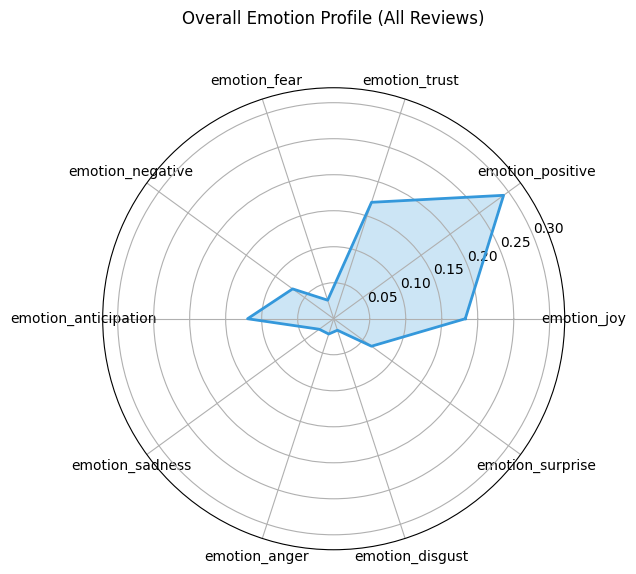

```python
# Select columns related to emotions and compute their average scores
emotion_columns = df.filter(like="emotion_").columns
avg_emotions_all = df[emotion_columns].mean().round(4)

# Prepare data for radar plot: labels, angles, and scores (closing the loop)
labels = avg_emotions_all.index.tolist()
angles = np.linspace(0, 2 * np.pi, len(labels), endpoint=False).tolist()
scores = avg_emotions_all.tolist() + [avg_emotions_all.iloc[0]]
angles += [angles[0]]

# Create radar plot with polar coordinates
fig, ax = plt.subplots(figsize=(6, 6), subplot_kw=dict(polar=True))

# Plot emotion scores and fill area under the curve
ax.plot(angles, scores, color=main_color, linewidth=2)
ax.fill(angles, scores, color=main_color, alpha=0.25)

# Set emotion labels around the plot in place of degree values
ax.set_thetagrids(np.degrees(angles[:-1]), labels, fontsize=10)

# Set title and radial limits
ax.set_title("Overall Emotion Profile (All Reviews)", y=1.12)
ax.set_ylim(0, avg_emotions_all.max() * 1.1)

# Display the radar chart
plt.show()
```

The above radar chart presents overall customer feedback in a structured emotional profile, offering a clear perspective into how diners emotionally engage with their restaurant experiences.

Joy and Trust indicate that the majority of patrons report positive emotional experiences. These likely stem from consistently strong elements such as friendly service, flavorful dishes, or a pleasant atmosphere. From a business standpoint, these emotional cues highlight clear strengths that can be leveraged in branding, marketing, and experience replication across other locations.

- Anger and Sadness may reflect frustrations with service quality, wait times, or unmet expectations.
- Anticipation, when high but accompanied by lower satisfaction, may indicate a mismatch between customer expectations and actual experience, which can affect repeat business and brand trust.

While this chart provides only a high-level summary, it serves as a helpful snapshot of general emotional patterns in customer feedback. It does not pinpoint specific causes, but it can guide further investigation into areas where sentiment is more mixed or less enthusiastic.

By interpreting these emotional trends in context with other data, we can better understand how guests respond to different aspects of their experience and prioritize areas that may need reinforcement, refinement, or deeper analysis.

## Topic Modeling

Before performing Latent Dirichlet Allocation for topic modeling, we added an additional preprocessing stage that filters the text to keep only specific parts of speech - namely nouns and adjectives - while removing stopwords and non-alphabetic tokens. While the broader set of parts of speech used earlier was effective for sentiment scoring, including verbs and other categories would introduce noise for LDA topic modeling and degrade the quality of the topics. This targeted filtering helps reduce noise and retain only the most meaningful words for LDA, improving the clarity and coherence of the resulting topics.

```python
def filter_for_lda(text: str) -> str:
    """
    Keep only nouns and adjectives from the text after lemmatizing.
    Removes stop words and non-alphabetic tokens.
    """
    doc = nlp(text)
    keep_pos: Set[str] = {"NOUN", "ADJ"}
    filtered_tokens = [
        token.lemma_ for token in doc
        if token.pos_ in keep_pos and not token.is_stop and token.is_alpha
    ]
    return " ".join(filtered_tokens)


# Apply filtering function to DataFrame column
df["lda_clean_text"] = df["clean_text"].apply(filter_for_lda)

# Preview filtered text
df["lda_clean_text"].head()
```

```
0                                        home day love
1                                          space pilot
2    great ambiance indoor attentive staff great fo...
3                         wrong wrong wrong fit escort
4                    bad server manager host rude liar
Name: lda_clean_text, dtype: object
```

Next, we convert the cleaned text into a matrix of word counts using CountVectorizer and test different numbers of topics for our LDA model. For each number of topics, we measure how well the model fits the data using log likelihood and perplexity scores. In the plots, we look for the number of topics where the log likelihood is highest and the perplexity is lowest - this helps us determine the best balance between model fit and complexity for our analysis.

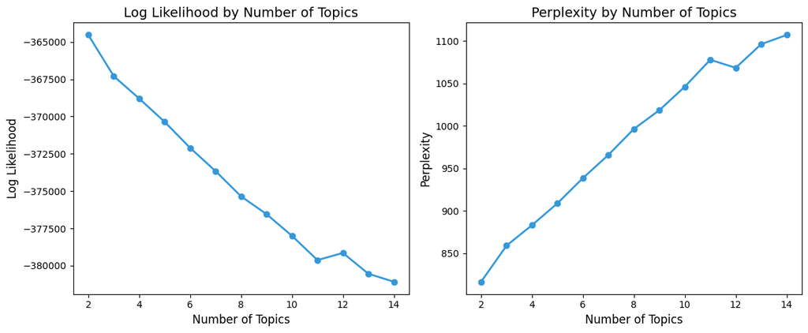

```python
def evaluate_lda_models(dtm: pd.Series, topic_range: range) -> Tuple[List[float], List[float]]:
    """
    Fits LDA models for a range of topic numbers and returns the log likelihoods
    and perplexities for each.
    """
    log_likelihoods = []
    perplexities = []

    for n_topics in topic_range:
        lda = LatentDirichletAllocation(n_components=n_topics, random_state=42)
        lda.fit(dtm)
        log_likelihoods.append(lda.score(dtm))
        perplexities.append(lda.perplexity(dtm))

    return log_likelihoods, perplexities


# Fit LDA models and gather evaluation metrics
topic_range = range(2, 15)
vectorizer = CountVectorizer(max_df=0.95, min_df=2, stop_words="english")
dtm = vectorizer.fit_transform(df["lda_clean_text"])
log_likelihoods, perplexities = evaluate_lda_models(dtm, topic_range)

# Plot log likelihood and perplexity across different topic numbers
plt.figure(figsize=(12, 5))

plt.subplot(1, 2, 1)
plt.plot(topic_range, log_likelihoods, marker="o", color=main_color, linewidth=2)
plt.title("Log Likelihood by Number of Topics", fontsize=14)
plt.xlabel("Number of Topics", fontsize=12)
plt.ylabel("Log Likelihood", fontsize=12)

plt.subplot(1, 2, 2)
plt.plot(topic_range, perplexities, marker="o", color=main_color, linewidth=2)
plt.title("Perplexity by Number of Topics", fontsize=14)
plt.xlabel("Number of Topics", fontsize=12)
plt.ylabel("Perplexity", fontsize=12)

plt.tight_layout()
plt.show()
```

While the evaluation metrics suggest that a very small number of topics may statistically fit the data best, such a low topic count offers limited insight into the diverse themes present in the reviews. To better capture meaningful distinctions and provide actionable insights about the features of Los Angeles restaurants, we opted to select a moderate number of topics (**5** in total). This choice balances interpretability with model robustness, allowing us to uncover a richer set of relevant topics that can guide recommendations for what aspects to adopt, improve, or promote in our analysis.

```python
# Fit LDA model and get topic proportions
selected_n_topics: int = 5
lda = LatentDirichletAllocation(n_components=selected_n_topics, random_state=42)
topic_proportions = lda.fit_transform(dtm)

# Convert topic proportions to a DataFrame
topic_df = pd.DataFrame(
    topic_proportions,
    columns=[f"Topic_{i}" for i in range(lda.n_components)]
)

# Combine topic proportions with the original DataFrame
df_sentiment_topic = pd.concat([df, topic_df], axis=1)

# Print top words for each topic
feature_names = vectorizer.get_feature_names_out()
n: int = 10  # Number of words to display per topic

for topic_idx, topic in enumerate(lda.components_):
    print(f"\nTopic {topic_idx}:")
    top_features_ind = topic.argsort()[:-n - 1:-1]
    top_words = [feature_names[i] for i in top_features_ind]
    print(" ".join(top_words))
```

```
Topic 0:
food experience restaurant service place dish time great good meal

Topic 1:
order food table time place good restaurant service nice dish

Topic 2:
good great food place service love fresh nice spot sandwich

Topic 3:
good food great amazing service place restaurant drink vibe ambiance

Topic 4:
good order dish time food flavor sauce spicy chicken restaurant
```

**Topic 0 - Dining Experience**

This topic captures the overall dining experience, encompassing key elements such as food quality, service, and the restaurant atmosphere. Terms like "meal," "great," and "good" indicate that customers reflect positively on their entire visit, highlighting satisfaction with both the dishes and the environment.

**Topic 1 - Order Service**

The focus here is on the practical aspects of dining, including ordering and table service. Customer comments emphasize interactions with staff, the timeliness of food delivery, and the smoothness of the dining experience, underscoring the importance of efficient service and comfortable seating.

**Topic 2 - Food Quality**

Emphasis is placed on food freshness and quality, with specific attention to items such as sandwiches. Positive language like "love" and "nice" suggests strong customer appreciation for taste and preparation, indicating satisfaction with ingredient quality and presentation.

**Topic 3 - Restaurant Atmosphere**

This topic highlights the restaurant’s atmosphere, combining references to food and service with a focus on drinks and overall ambiance. It reflects that customers value not only the culinary offerings but also the social and environmental setting during their visits.

**Topic 4 - Flavor Profile**

Focus is placed on the flavor profiles of dishes, particularly the use of spices and seasoning. Mentions of items like "chicken" and "sauce" reveal attention to taste complexity, indicating the restaurant’s ability to meet diverse flavor preferences effectively.

**Summary**

These topics reveal key areas where a restaurant can gain a competitive edge. Delivering a consistently positive dining experience by balancing great food, attentive service, and a welcoming atmosphere will leave a strong impression on customers. Efficient order and table service also matter, ensuring guests feel well cared for and comfortable. High food quality, especially freshness and preparation, stands out as a major driver of satisfaction. Creating a vibrant restaurant atmosphere enhances the overall visit, making it memorable beyond just the meal. Finally, paying close attention to flavor profiles and seasoning helps meet diverse tastes, further setting the restaurant apart from competitors.

## Sentiment Analysis by Topic

### Polarity Sentiment

Previously, we calculated the average **polarity score** for each dominant topic. The polarities to recap are:

- **> 0** → Positive sentiment
- **< 0** → Negative sentiment
- **≈ 0** → Neutral sentiment

Here are the average polarity scores by topic:

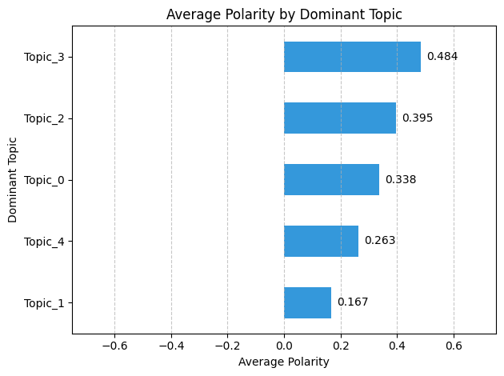

```python
# Assign the dominant topic for each document based on highest topic proportion
df_sentiment_topic["dominant_topic"] = topic_df.idxmax(axis=1)

# Calculate average polarity score by dominant topic and format as DataFrame
avg_polarity_by_topic: pd.DataFrame = (
    df_sentiment_topic
    .groupby("dominant_topic")["polarity"]
    .mean()
    .round(3)
    .to_frame()
)

# Sort polarity values from highest to lowest before plotting
sorted_polarity: pd.DataFrame = avg_polarity_by_topic.sort_values(by="polarity", ascending=True)

plt.figure(figsize=(8, 5))
ax = sorted_polarity.plot(kind='barh', color=main_color, legend=False)

plt.xlabel("Average Polarity")
plt.ylabel("Dominant Topic")
plt.title("Average Polarity by Dominant Topic")
plt.grid(axis='x', linestyle='--', alpha=0.7)
plt.xlim(-0.75, 0.75)

# Annotate each bar with its value to 3 decimal places
for i, (index, row) in enumerate(sorted_polarity.iterrows()):
    value = row["polarity"]
    ax.text(value + 0.02 if value >= 0 else value - 0.08, i, f"{value:.3f}", va='center')

plt.tight_layout()
plt.show()
```

**Topic 0 - Dining Experience**

With an average polarity of approximately 0.34, this topic reflects generally positive sentiment about the overall dining experience, including food, service, and meal enjoyment. Customers appreciate the core aspects of visiting the restaurant, though there may be opportunities to improve consistency and elevate certain elements to enhance satisfaction further.

**Topic 1 - Order Service**

This topic shows a moderate positive sentiment with an average polarity around 0.17. It highlights customer experiences related to ordering and table service logistics. The more neutral tone indicates some customers might encounter occasional issues such as wait times, order accuracy, or service interactions, suggesting room for operational improvements.

**Topic 2 - Food Quality**

At an average polarity of about 0.40, this topic centers on food quality and freshness, especially items like sandwiches. The relatively high positive sentiment indicates that customers are generally satisfied with the taste and quality of the food, marking it as a strong component of the restaurant’s appeal.

**Topic 3 - Restaurant Atmosphere**

This topic has the highest average polarity of roughly 0.48, emphasizing the restaurant’s ambiance, drinks, and overall vibe. Strong positive sentiment here suggests that the atmosphere is a key driver of memorable and enjoyable dining experiences, making it one of the restaurant’s standout features.

**Topic 4 - Flavor Profile**

With an average polarity near 0.26, this topic relates to flavor, spices, and specific dishes like chicken. The moderate positive sentiment suggests that while customers appreciate the seasoning and taste, there is potential to refine flavor profiles further to increase customer delight and satisfaction.

**Summary**

The polarity scores highlight clear strengths and opportunities for restaurants aiming to stand out. The highest positive sentiment around atmosphere and vibe suggests that investing in creating a welcoming, memorable ambiance can significantly boost customer satisfaction. Strong food quality, especially freshness and well-prepared dishes like sandwiches, is also a key competitive advantage. Meanwhile, more neutral sentiment in order service and certain flavor aspects points to areas where improvements - such as faster service, order accuracy, and flavor refinement - could enhance the overall experience and help differentiate the restaurant in a competitive market.

### Emotion Sentiment

| dominant_topic | emotion_joy | emotion_positive | emotion_trust | emotion_fear | emotion_negative | emotion_anticipation | emotion_sadness | emotion_anger | emotion_disgust | emotion_surprise |
| --- | --- | --- | --- | --- | --- | --- | --- | --- | --- | --- |
| Topic_0 | 0.181 | 0.306 | 0.169 | 0.024 | 0.068 | 0.114 | 0.029 | 0.023 | 0.017 | 0.060 |
| Topic_1 | 0.134 | 0.257 | 0.155 | 0.039 | 0.111 | 0.133 | 0.038 | 0.037 | 0.027 | 0.056 |
| Topic_2 | 0.199 | 0.304 | 0.170 | 0.029 | 0.061 | 0.102 | 0.022 | 0.021 | 0.016 | 0.062 |
| Topic_3 | 0.213 | 0.304 | 0.186 | 0.015 | 0.042 | 0.121 | 0.017 | 0.013 | 0.008 | 0.072 |
| Topic_4 | 0.168 | 0.281 | 0.161 | 0.035 | 0.086 | 0.126 | 0.026 | 0.024 | 0.022 | 0.068 |

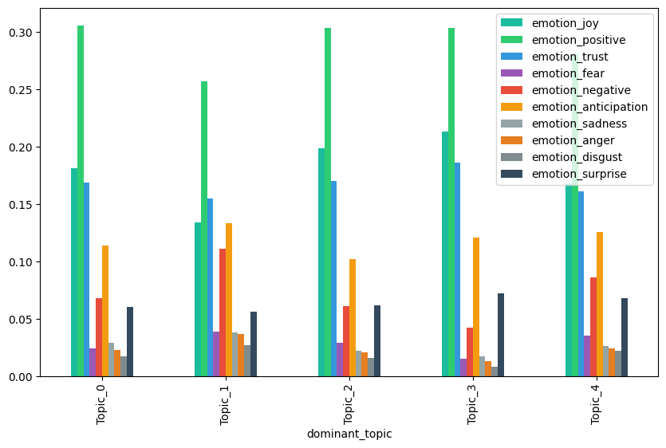

```python
# Select columns related to emotions
emotion_cols = df_sentiment_topic.filter(like="emotion").columns

# Calculate average emotion scores by dominant topic
avg_emotions_by_topic: pd.DataFrame = (
    df_sentiment_topic
    .groupby("dominant_topic")[emotion_cols]
    .mean()
    .round(3)
)

display(avg_emotions_by_topic)

# Ensure the order of colors matches the column order
colors = [emotion_colors[col] for col in avg_emotions_by_topic.columns]

avg_emotions_by_topic.plot(kind='bar', figsize=(10, 6), color=colors)
```

**Topic 0 - Dining Experience**

This topic shows relatively high levels of positive emotions such as joy (0.181), positivity (0.306), and trust (0.169), with low negative emotions like fear (0.024) and anger (0.023). The emotional profile indicates that customers generally feel happy, confident, and satisfied with the overall dining experience, reinforcing its role as a strong foundation of customer satisfaction.

**Topic 1 - Order Service**

Compared to other topics, this one has lower positive emotion scores (joy 0.134, positive 0.257) and elevated negative emotions, including fear (0.039), negativity (0.111), sadness (0.038), anger (0.037), and disgust (0.027). This suggests customers occasionally experience frustration or dissatisfaction related to ordering and table service, highlighting operational areas for improvement.

**Topic 2 - Food Quality**

Emotion scores show high joy (0.199), positivity (0.304), and trust (0.170), alongside low negative emotions, mirroring the strong favorable sentiment toward food freshness and quality. This emotional pattern reflects genuine customer appreciation for well-prepared, tasty dishes, reinforcing food quality as a key strength.

**Topic 3 - Restaurant Atmosphere**

This topic stands out with the highest joy (0.213) and trust (0.186) scores and the lowest negative emotions overall (fear 0.015, negativity 0.042, anger 0.013). The emotional balance confirms the atmosphere as a critical driver of positive, memorable dining experiences, contributing significantly to customer delight.

**Topic 4 - Flavor Profile**

Here, positive emotions remain strong (joy 0.168, positive 0.281, trust 0.161) but negative emotions like fear (0.035), negativity (0.086), and disgust (0.022) are somewhat elevated compared to the strongest topics. This indicates that while customers generally enjoy the flavor and seasoning, there is still room to fine-tune tastes and reduce occasional negative reactions.

**Summary**

These emotion scores complement the polarity results by highlighting where positive feelings are strongest and where negative emotions persist. Focusing on enhancing the dining atmosphere and food quality aligns well with the areas of highest joy and trust, while addressing operational challenges in order service and refining flavor profiles can help reduce negative emotions, ultimately improving the overall customer experience and competitive positioning.

## Star Rating Analysis by Topic

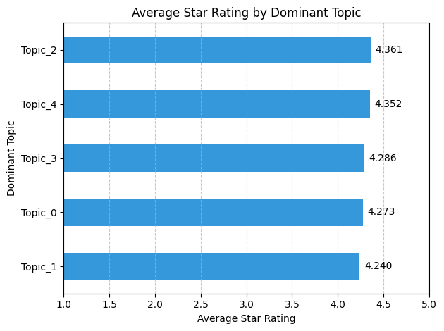

```python
# Calculate average star rating by dominant topic
avg_rating_by_topic: pd.DataFrame = (
    df_sentiment_topic
    .groupby("dominant_topic")["StarRating"]
    .mean()
    .round(3)
    .to_frame()
    .sort_values(by="StarRating", ascending=True)
)

# Plot average star rating by dominant topic
plt.figure(figsize=(8, 5))
ax = avg_rating_by_topic.plot(kind='barh', color=main_color, legend=False)

plt.xlabel("Average Star Rating")
plt.ylabel("Dominant Topic")
plt.title("Average Star Rating by Dominant Topic")
plt.grid(axis='x', linestyle='--', alpha=0.7)
plt.xlim(1, 5)

# Annotate each bar with its value to 3 decimal places
for i, (index, row) in enumerate(avg_rating_by_topic.iterrows()):
    value = row["StarRating"]
    ax.text(value + 0.05 if value < 5 else value - 0.2, i, f"{value:.3f}", va='center')

plt.tight_layout()
plt.show()
```

**Topic 0 - Dining Experience**

*Avg. Rating: 4.27*

This topic reflects overall impressions of the dining experience, including the setting, timing, and flow. While the average rating is strong, the slight dip compared to others may point to minor inconsistencies in ambiance or pacing. We recommend monitoring this area for experience gaps that might impact overall satisfaction.

**Topic 1 - Order Service**

*Avg. Rating: 4.24*

This is the lowest-rated topic in our analysis, though it still performs well overall. Reviews here frequently mention ordering, wait times, and service accuracy. We believe even small operational improvements in order flow or front-of-house interactions could meaningfully elevate customer perceptions.

**Topic 2 - Food Quality**

*Avg. Rating: 4.36*

This is the highest-rated topic, strongly highlighting customer satisfaction with the freshness and preparation of dishes. This consistently strong feedback indicates that current efforts in the kitchen are resonating well with guests.

**Topic 3 - Restaurant Atmosphere**

*Avg. Rating: 4.29*

This topic centers on ambiance and environment. Customers respond positively to the restaurant's vibe, layout, and decor. We see this as a competitive strength worth reinforcing - particularly in customer-facing branding and visuals.

**Topic 4 - Flavor Profile**

*Avg. Rating: 4.35*

This also ranks near the top and captures commentary around how food tastes - flavor, seasoning, and balance. The data suggests guests are highly satisfied in this area, with only rare mentions of overly strong or underwhelming flavor profiles.

**Summary**

Food quality and flavor profile are clear differentiators that drive high ratings. Atmosphere further reinforces the positive experience. However, service and ordering processes present a relative opportunity for improvement. We recommend focusing optimization efforts on service consistency while maintaining the strengths already reflected in food and ambiance.

# Business Recommendations

As part of our review of customer sentiment, emotional tone, and thematic content across a wide range of restaurant reviews in Los Angeles, we identified consistent patterns in what diners value most - and what tends to frustrate them. The analysis spans thousands of reviews and was conducted to help you, our client, position your own restaurant competitively within the local market by learning from shared industry strengths and pain points.

### Leverage Ambiance as a Competitive Advantage

By strategically addressing these areas - particularly ambiance, food quality, and emotional tone - you can elevate your restaurant’s position in the competitive Los Angeles dining landscape. These recommendations are built not only on sentiment patterns but also on empirical metrics that reflect the true drivers of customer satisfaction and loyalty in this market. We would be happy to support implementation or ongoing monitoring as needed.